# Python_HW8_byK

```python
import numpy as np
import matplotlib.pyplot as plt
from mpl_toolkits.mplot3d import Axes3D
import time
```

```python
# Set plot params
plt.rcParams['figure.figsize'] = [5,5]
plt.rcParams['font.size'] = 10
plt.rcParams['font.family'] = 'Times New Roman'
plt.rcParams['axes.linewidth'] = 2
plt.rcParams['lines.linewidth'] = 2
plt.rcParams['xtick.direction'] = 'out'
plt.rcParams['ytick.direction'] = 'out'
plt.rcParams['xtick.minor.visible'] = True
plt.rcParams['ytick.minor.visible'] = True
plt.rcParams['xtick.major.size'] = 7
plt.rcParams['ytick.major.size'] = 7
plt.rcParams['xtick.minor.size'] = 3.5
plt.rcParams['ytick.minor.size'] = 3.5
plt.rcParams['xtick.major.width'] = 1.5
plt.rcParams['ytick.major.width'] = 1.5
plt.rcParams['xtick.minor.width'] = 1.5
plt.rcParams['ytick.minor.width'] = 1.5
plt.rcParams['xtick.top'] = True
plt.rcParams['ytick.right'] = True
```

Two-dimensional Poisson equation is written as $$ \nabla^2 u(x, y)=f(x, y) \quad \text { for } \quad(x, y) \in \Omega $$ and on the boundary $\partial \Omega=\partial \Omega_D \cup \partial \Omega_N$ $$ u(x, y)=g(x, y) \quad \text { on } \quad \partial \Omega_D \quad \text { and } \quad \partial u / \partial n=h(x, y) \quad \text { on } \quad \partial \Omega_N $$ Note that $n$ is the normal to the boundary, $\partial \Omega_D$ is the Dirichlet boundary, and $\partial \Omega_N$ is the Neumann boundary.

1. (Iterative Poisson solver) Let's consider the Poisson equation in the square domain $[0,1] \times[0,1]$ with homogenous boundary conditions $u=0$ at all boundaries and $f(x, y)=\sin (\pi x) \sin (\pi y)$.

(1) Develop iterative Poisson solvers based on 1) Jacobi method, 2) Gauss-Seidel methods, 3) GaussSeidel method with successive over-relaxation (SOR). You may consider the equation is discretized on a uniform grid using the five-point scheme.

1) Jacobi method

```python
def jacobi_solver(f, g, h, max_iterations=1000, tol=1e-6):
    # Grid size
    N = len(f) - 1
    h_sq = h**2

    # Initialize solution

    u = np.zeros((N+1, N+1))

    # Perform iterations
    for iteration in range(max_iterations):
        u_new = np.copy(u)

        for i in range(1, N):
            for j in range(1, N):
                u_new[i, j] = 0.25 * (u[i-1, j] + u[i+1, j] + u[i, j-1] + u[i, j+1] - h_sq * f[i, j])

        # Apply boundary conditions
        u_new[0, :] = g[0, :]  # Bottom boundary
        u_new[N, :] = g[N, :]  # Top boundary
        u_new[:, 0] = g[:, 0]  # Left boundary
        u_new[:, N] = g[:, N]  # Right boundary

        # Check convergence
        if np.linalg.norm(u_new - u) < tol:
            break

        u = np.copy(u_new)

    return u
```

```python
# Parameters
N = 10  # Number of grid points in each direction
h = 1 / N  # Grid spacing
x = np.linspace(0, 1, N+1)
y = np.linspace(0, 1, N+1)
X, Y = np.meshgrid(x, y)

# Compute the forcing function
f = np.sin(np.pi * X) * np.sin(np.pi * Y)

# Compute the boundary conditions
g = np.zeros((N+1, N+1))

# Solve using methods and compute time
times=[]
start = time.time()
Ju = jacobi_solver(f, g, h)
end = time.time()
com_time = end - start
times.append(com_time)
```

2) Gauss-Seidel methods

```python
def gauss_seidel_solver(f, g, h, max_iterations=1000, tol=1e-6):
    # Grid size
    N = len(f) - 1
    h_sq = h**2

    # Initialize solution
    u = np.zeros((N+1, N+1))

    # Perform iterations
    for iteration in range(max_iterations):
        for i in range(1, N):
            for j in range(1, N):
                u_new = 0.25 * (u[i-1, j] + u[i+1, j] + u[i, j-1] + u[i, j+1] - h_sq * f[i, j])
                diff = np.linalg.norm(u - u_new)
                u[i,j] = u_new

        # Apply boundary conditions
        u[0, :] = g[0, :]  # Bottom boundary
        u[N, :] = g[N, :]  # Top boundary
        u[:, 0] = g[:, 0]  # Left boundary
        u[:, N] = g[:, N]  # Right boundary

        # Check convergence
        if diff < tol:
            break

    return u
```

```python
# Parameters
N = 10  # Number of grid points in each direction
h = 1 / N  # Grid spacing
x = np.linspace(0, 1, N+1)
y = np.linspace(0, 1, N+1)
X, Y = np.meshgrid(x, y)

# Compute the forcing function
f = np.sin(np.pi * X) * np.sin(np.pi * Y)

# Compute the boundary conditions
g = np.zeros((N+1, N+1))

# Solve using methods and compute time
start = time.time()
GSu = gauss_seidel_solver(f, g, h)
end = time.time()
com_time = end - start
times.append(com_time)
```

3) GaussSeidel method with successive over-relaxation (SOR)

```python
def sor_solver(f, g, h, omega, max_iterations=1000, tol=1e-6):
    # Grid size
    N = len(f) - 1
    h_sq = h**2

    # Initialize solution
    u = np.zeros((N+1, N+1))

    # Perform iterations
    for iteration in range(max_iterations):
        for i in range(1, N):
            for j in range(1, N):
                u_new = (1 - omega) * u[i, j] + omega * 0.25 * (u[i-1, j] + u[i+1, j] + u[i, j-1] + u[i, j+1] - h_sq * f[i, j])
                diff = np.linalg.norm(u - u_new)
                u[i,j] = u_new

        # Apply boundary conditions
        u[0, :] = g[0, :]  # Bottom boundary
        u[N, :] = g[N, :]  # Top boundary
        u[:, 0] = g[:, 0]  # Left boundary
        u[:, N] = g[:, N]  # Right boundary

        # Check convergence
        if diff < tol:
            break

    return u
```

```python
# Parameters
N = 10  # Number of grid points in each direction
h = 1 / N  # Grid spacing
x = np.linspace(0, 1, N+1)
y = np.linspace(0, 1, N+1)
X, Y = np.meshgrid(x, y)

# Compute the forcing function
f = np.sin(np.pi * X) * np.sin(np.pi * Y)

# Compute the boundary conditions
g = np.zeros((N+1, N+1))

# Solve using methods and compute time
omega = 1.5
start = time.time()
SORu = sor_solver(f, g, h, omega)
end = time.time()
com_time = end - start
times.append(com_time)
```

(1) Results

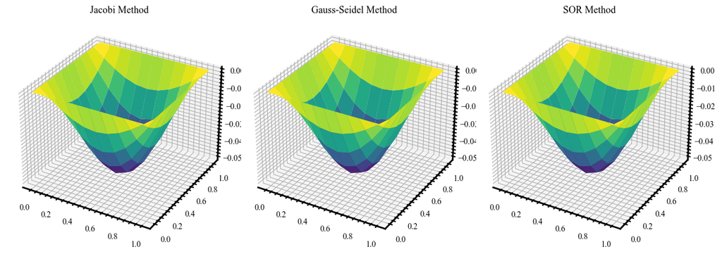

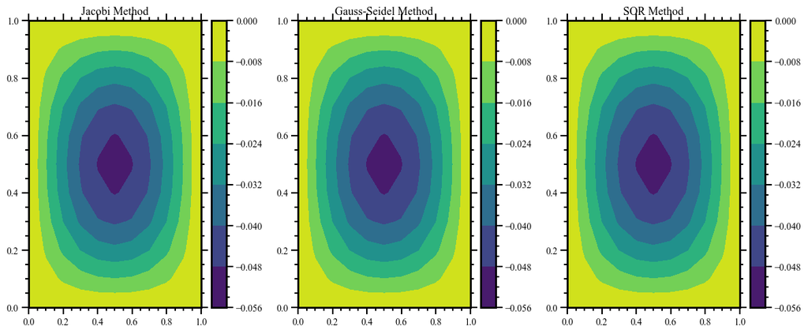

```python
# Create meshgrid for 3D plot
X, Y = np.meshgrid(x, y)

# Plot 3D surface
fig = plt.figure(figsize=(12, 5))

# Jacobi method
ax1 = fig.add_subplot(1, 3, 1, projection='3d')
ax1.plot_surface(X, Y, Ju, cmap='viridis')
ax1.set_title('Jacobi Method')

# Gauss-Seidel method
ax2 = fig.add_subplot(1, 3, 2, projection='3d')
ax2.plot_surface(X, Y, GSu, cmap='viridis')
ax2.set_title('Gauss-Seidel Method')

# SOR method
ax3 = fig.add_subplot(1, 3, 3, projection='3d')
ax3.plot_surface(X, Y, SORu, cmap='viridis')
ax3.set_title('SOR Method')

plt.tight_layout()
plt.show()

# Plot contour
plt.figure(figsize=(12, 5))

# Jacobi method
plt.subplot(1, 3, 1)
plt.contourf(X, Y, Ju, cmap='viridis')
plt.colorbar()
plt.title('Jacobi Method')

# Gauss-Seidel method
plt.subplot(1, 3, 2)
plt.contourf(X, Y, GSu, cmap='viridis')
plt.colorbar()
plt.title('Gauss-Seidel Method')

# SOR method
plt.subplot(1, 3, 3)
plt.contourf(X, Y, SORu, cmap='viridis')
plt.colorbar()
plt.title('SOR Method')

plt.tight_layout()
plt.show()
```

(2) Show the performance of the iteration methods. You may consider the norm of residual, errors, computational time, etc for the performance evaluation.

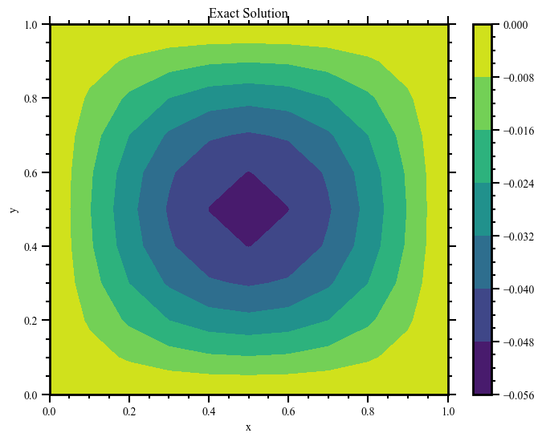

```python
# Parameters
N = 10  # Number of grid points in each direction
x = np.linspace(0, 1, N+1)
y = np.linspace(0, 1, N+1)
X, Y = np.meshgrid(x, y)

# Compute the exact solution
u_exact = -(1 / (2 * np.pi**2)) * np.sin(np.pi * X) * np.sin(np.pi * Y)

# Plot the exact solution
plt.figure(figsize=(8, 6))
plt.contourf(X, Y, u_exact, cmap='viridis')
plt.colorbar()
plt.title('Exact Solution')
plt.xlabel('x')
plt.ylabel('y')
plt.show()
```

```python
# Parameters
N = 10  # Number of grid points in each direction
h = 1 / N  # Grid spacing
x = np.linspace(0, 1, N+1)
y = np.linspace(0, 1, N+1)
X, Y = np.meshgrid(x, y)

# Compute the forcing function
f = np.sin(np.pi * X) * np.sin(np.pi * Y)

# Compute the boundary conditions
g = np.zeros((N+1, N+1))

# Set the relaxation parameter for SOR
omega = 1.5

# Compute the exact solution
u_exact = -(1 / (2 * np.pi**2)) * np.sin(np.pi * X) * np.sin(np.pi * Y)

# Initialize performance metrics
ress = []
errors = []

# Compute residual and errors (2-norms)

# Jacobi
Jres = np.linalg.norm(f[1:-1,1:-1] - (Ju[1:-1, 1:-1] - (4 * Ju[1:-1, 1:-1] - Ju[:-2, 1:-1] - Ju[2:, 1:-1] - Ju[1:-1, :-2] - Ju[1:-1, 2:]) / h**2))
Jerr = np.linalg.norm(u_exact[1:-1, 1:-1] - Ju[1:-1, 1:-1])

# Solve using Gauss-Seidel method
GSres = np.linalg.norm(f[1:-1,1:-1] - (GSu[1:-1, 1:-1] - (4 * GSu[1:-1, 1:-1] - GSu[:-2, 1:-1] - GSu[2:, 1:-1] - GSu[1:-1, :-2] - GSu[1:-1, 2:]) / h**2))
GSerr = np.linalg.norm(u_exact[1:-1, 1:-1] - GSu[1:-1, 1:-1])

# Solve using SOR method
SORres = np.linalg.norm(f[1:-1,1:-1] - (SORu[1:-1, 1:-1] - (4 * SORu[1:-1, 1:-1] - SORu[:-2, 1:-1] - SORu[2:, 1:-1] - SORu[1:-1, :-2] - SORu[1:-1, 2:]) / h**2))
SORerr = np.linalg.norm(u_exact[1:-1, 1:-1] - SORu[1:-1, 1:-1])

# Print performance metrics
print("\n[Residuals]")
print("Jacobi: ", Jres)
print("Gauss-Seidel: ", GSres)
print("SOR: ", SORres)

print("\n[Errors]")
print("Jacobi: ", Jerr)
print("Gauss-Seidel: ", GSerr)
print("SOR: ", SORerr)

print("\n[Computational Times]")
print("Jacobi: ", times[0])
print("Gauss-Seidel: ", times[1])
print("SOR: ", times[2])
```

```
[Residuals]
Jacobi:  0.25577591916141085
Gauss-Seidel:  0.25539661368163613
SOR:  0.2553966136816345

[Errors]
Jacobi:  0.002073236992443005
Gauss-Seidel:  0.0020936545757891094
SOR:  0.0020936545757893666

[Computational Times]
Jacobi:  0.03568387031555176
Gauss-Seidel:  0.7436721324920654
SOR:  0.8028450012207031
```

1. (Linearity) Let's consider a following Poisson equation $$ \nabla^2 u(x, y)=f_1(x, y)+f_2(x, y) \quad \text { for } \quad(x, y) \in \Omega $$ and $u(x, y)=0$ on the boundary $\partial \Omega$ of the square domain $\Omega \equiv[0,1] \times[0,1]$.

(1) Find $u(x, y)$, the solution of Poisson equation, $\nabla^2 u(x, y)=f_1(x, y)+f_2(x, y)$ using Gauss-Seidel SOR. The forcing functions are defined as $$ \begin{gathered} f_1(x, y)=\sin (\pi x) \sin (\pi y) \\ f_2(x, y)=\exp \left(-100.0\left((x-0.5)^2+(y-0.5)^2\right)\right) \end{gathered} $$

```python
def poisson_solver(f1, f2, h, omega, max_iterations=1000, tol=1e-6):
    # Grid size
    N = len(f1) - 1
    h_sq = h**2

    # Initialize solution
    u = np.zeros((N+1, N+1))

    # Perform iterations
    for iteration in range(max_iterations):
        for i in range(1, N):
            for j in range(1, N):
                u_new = (1 - omega) * u[i, j] + omega * 0.25 * (u[i-1, j] + u[i+1, j] + u[i, j-1] + u[i, j+1] - h_sq * (f1[i, j] + f2[i, j]))
                diff = np.linalg.norm(u_new - u)
                u[i,j] = u_new

        # Check convergence
        if diff < tol:
            break

    return u
```

```python
# Parameters
N = 10  # Number of grid points in each direction
h = 1 / N  # Grid spacing
x = np.linspace(0, 1, N+1)
y = np.linspace(0, 1, N+1)
X, Y = np.meshgrid(x, y)

# Compute the forcing function
f = np.sin(np.pi * X) * np.sin(np.pi * Y)

# Compute the boundary conditions
g = np.zeros((N+1, N+1))

# Set the relaxation parameter for SOR
omega = 1.5
```

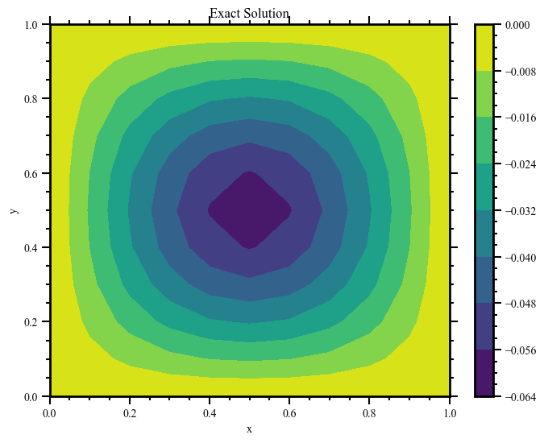

```python
# Compute the forcing functions
f1 = np.sin(np.pi * X) * np.sin(np.pi * Y)
f2 = np.exp(-100.0 * ((X - 0.5)**2 + (Y - 0.5)**2))

# Solve the Poisson equation
forceSORu = poisson_solver(f1, f2, h, omega)

# Plot the exact solution
plt.figure(figsize=(8, 6))
plt.contourf(X, Y, forceSORu, cmap='viridis')
plt.colorbar()
plt.title('Exact Solution')
plt.xlabel('x')
plt.ylabel('y')
plt.show()
```

(2) Find $u_2(x, y)$ the solution of Poisson equation, $\nabla^2 u_2(x, y)=f_2(x, y)$ using Gauss-Seidel SOR.

```python
# Parameters
N = 10  # Number of grid points in each direction
h = 1 / N  # Grid spacing
x = np.linspace(0, 1, N+1)
y = np.linspace(0, 1, N+1)
X, Y = np.meshgrid(x, y)

# Compute the forcing function
f = np.sin(np.pi * X) * np.sin(np.pi * Y)

# Compute the boundary conditions
g = np.zeros((N+1, N+1))

# Set the relaxation parameter for SOR
omega = 1.5
```

```python
# Solve the Poisson equation
SORu2 = sor_solver(f2, g, h, omega, max_iterations=1000, tol=1e-6)
```

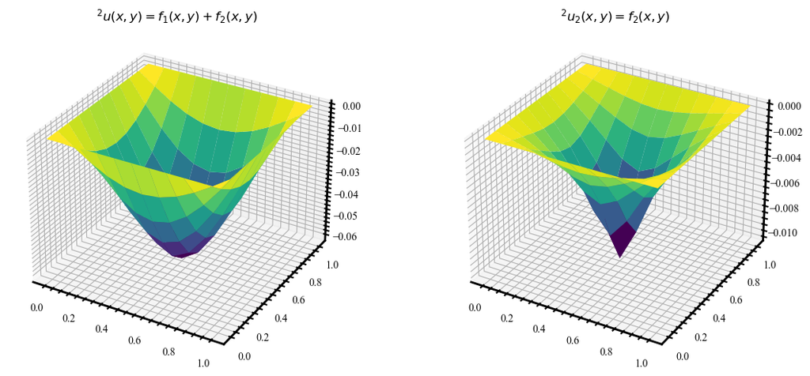

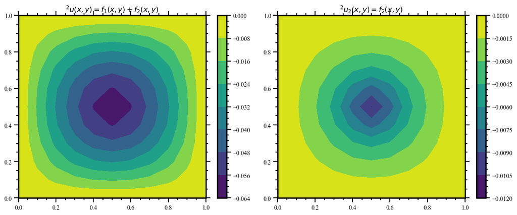

```python
# Create meshgrid for 3D plot
X, Y = np.meshgrid(x, y)

# Plot 3D surface
fig = plt.figure(figsize=(12, 5))

# f1 and f2 SOR
ax1 = fig.add_subplot(1, 2, 1, projection='3d')
ax1.plot_surface(X, Y, forceSORu, cmap='viridis')
ax1.set_title('$^2u(x,y) = f_1(x,y) + f_2(x,y)$')

# f2 SOR
ax2 = fig.add_subplot(1, 2, 2, projection='3d')
ax2.plot_surface(X, Y, SORu2, cmap='viridis')
ax2.set_title('$^2u_2(x,y) = f_2(x,y)$')

plt.tight_layout()
plt.show()

# Plot contour
plt.figure(figsize=(12, 5))

# f1 and f2 SOR
plt.subplot(1, 2, 1)
plt.contourf(X, Y, forceSORu, cmap='viridis')
plt.colorbar()
plt.title('$^2u(x,y) = f_1(x,y) + f_2(x,y)$')

# f2 SOR
plt.subplot(1, 2, 2)
plt.contourf(X, Y, SORu2, cmap='viridis')
plt.colorbar()
plt.title('$^2u_2(x,y) = f_2(x,y)$')

plt.tight_layout()
plt.show()
```

(3) Discuss the solution $u(x, y)$ by comparing with the solutions $u_2(x, y)$ and $u_1(x, y)$ that is obtained in Problem 1.

```
Error u:  2.7755575615628914e-17
```

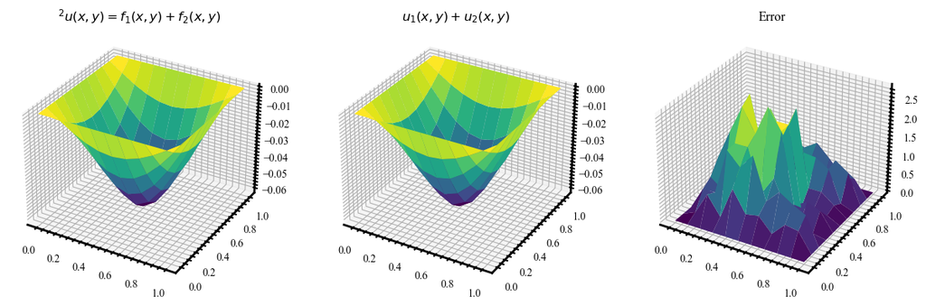

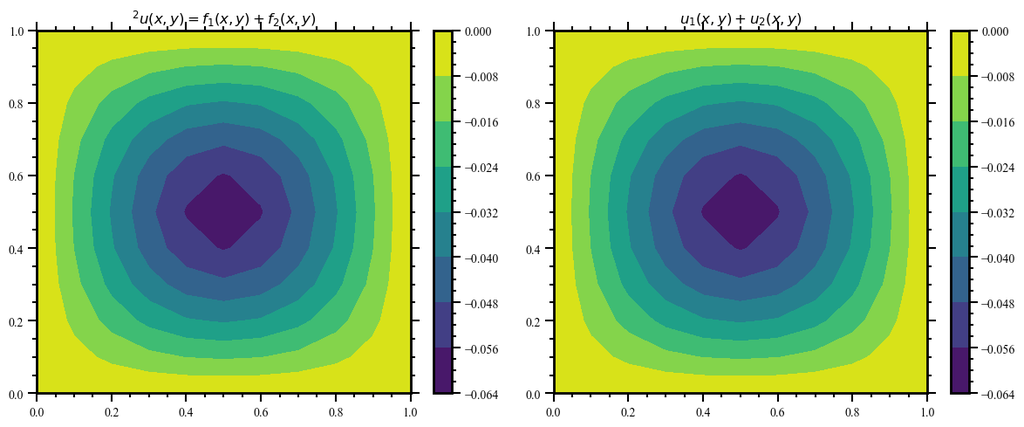

```python
# u = this problem solution
# u1 = SORu (Problem 1)
# u2 = SORu2 : f2's solution

# Compute the errors
errors = np.abs(forceSORu - SORu - SORu2)
error_u = np.max(errors)

# Print the errors
print("Error u: ", error_u)

# Create meshgrid for 3D plot
X, Y = np.meshgrid(x, y)

# Plot 3D surface
fig = plt.figure(figsize=(15, 5))

# f1 and f2 SOR
ax1 = fig.add_subplot(1, 3, 1, projection='3d')
ax1.plot_surface(X, Y, forceSORu, cmap='viridis')
ax1.set_title('$^2u(x,y) = f_1(x,y) + f_2(x,y)$')

# u1 + u2
ax2 = fig.add_subplot(1, 3, 2, projection='3d')
ax2.plot_surface(X, Y, SORu + SORu2, cmap='viridis')
ax2.set_title('$u_1(x,y) + u_2(x,y)$')

# u1 + u2
ax2 = fig.add_subplot(1, 3, 3, projection='3d')
ax2.plot_surface(X, Y, errors, cmap='viridis')
ax2.set_title('Error')

plt.show()

# Plot contour
plt.figure(figsize=(12, 5))

# f1 and f2 SOR
plt.subplot(1, 2, 1)
plt.contourf(X, Y, forceSORu, cmap='viridis')
plt.colorbar()
plt.title('$^2u(x,y) = f_1(x,y) + f_2(x,y)$')

# u1 + u2
plt.subplot(1, 2, 2)
plt.contourf(X, Y, SORu + SORu2, cmap='viridis')
plt.colorbar()
plt.title('$u_1(x,y) + u_2(x,y)$')

plt.tight_layout()
plt.show()
```

solution u와 f1에 대한 solution u1, f2에 대한 solution u2에 대해 고려해 보자.  
solution u와 u1+u2의 plot을 보면, 굉장히 유사한 것을 알수있는데,  
이때 둘 사이의 error = |u - (u1+u2)|로 계산해보면 중심으로 갈수록 에러가 커지는 것을 볼 수 있다.